# Assignment 6: Visualization - Aesthetic Mapping

*How to do it?*:

- Open the Rmarkdown file of this assignment (link) in Rstudio.
- Right under each **question**, insert a code chunk (you can use the hotkey `Ctrl + Alt + I` to add a code chunk) and code the solution for the question.
- `Knit` the rmarkdown file (hotkey: `Ctrl + Alt + K`) to export an html.
- Publish the html file to your Githiub Page.

*Submission*: Submit the link on Github of the assignment to Canvas.

### Questions on Your Selected Data

Choose a dataset and produce the following types of plots and comment on each plot. Plots should be meaningful. If you use the data we used in class, make sure the plots are not the same as the ones in the slides.

1. For one continuous variable:
- Density

```r
library(tidyverse)
```

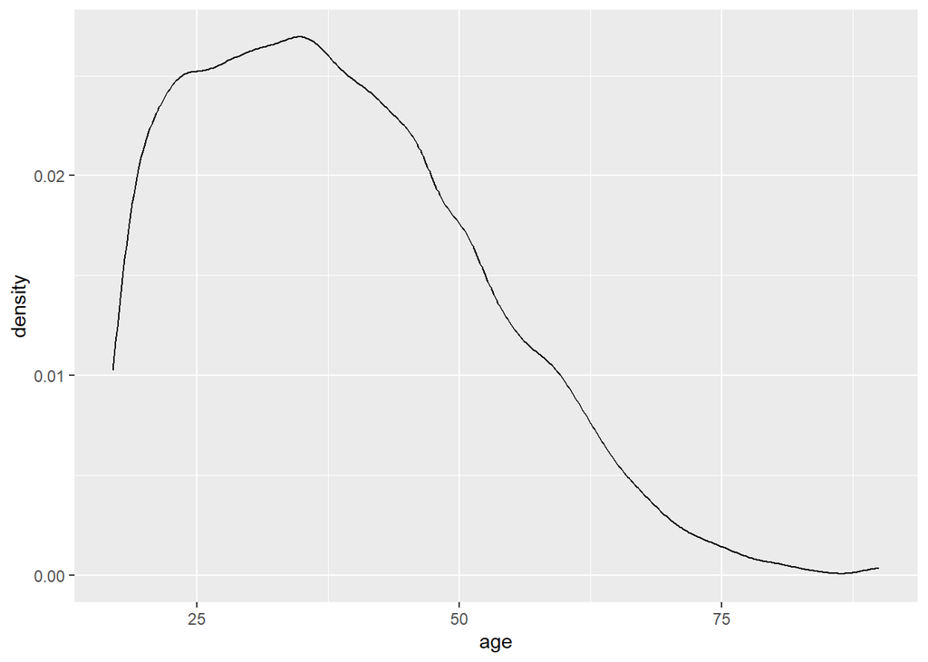

```r
library(ggplot2)
setwd("~/GitHub/MATH421")
df1 = read_csv('adult_census.csv')
df1 <- df1 %>%
  mutate(hours.per.week = as.numeric(hours.per.week),
         capital.loss = as.numeric(capital.loss),
         age = as.numeric(age))
df1 %>% ggplot()+
    geom_density(mapping = aes(x = age))
```

There’s a peak on the left because most of the observations are younger with a few older.

- Histogram

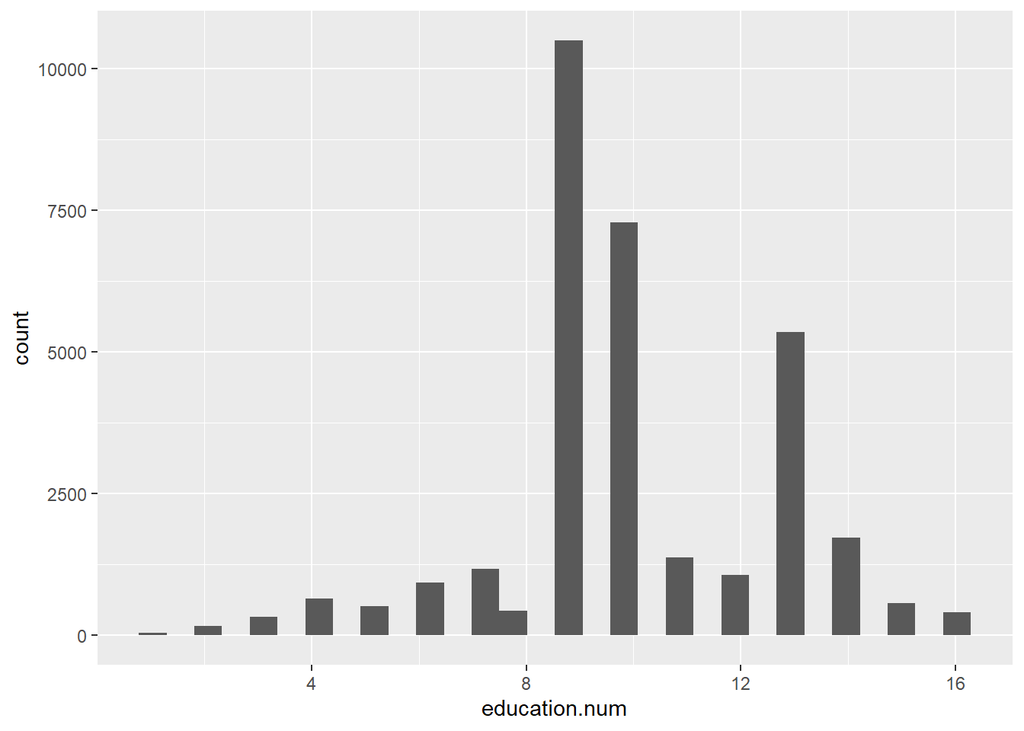

```r
df1 %>% ggplot()+
    geom_histogram(mapping = aes(x = education.num))
```

More people have an education number between 10 and 15, undergrad and beyond.

- Boxplot

[figure not shown]

```r
df1 %>% ggplot()+
  geom_boxplot(mapping = aes(x = sex))
```

2. For one categorical variable
- Barplot

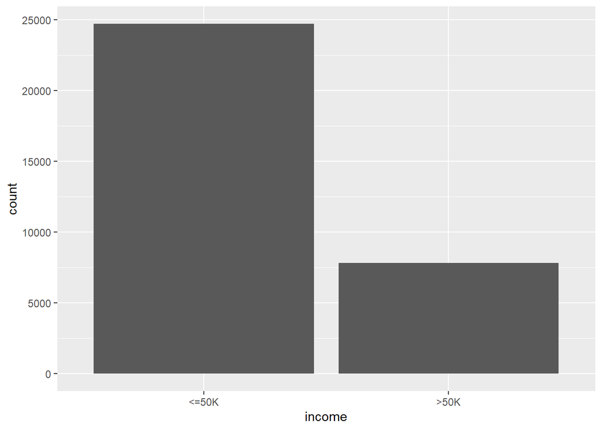

```r
df1 %>% ggplot()+
    geom_bar(mapping = aes(x = income))
```

## There are more observations with an income less than 50k than those earning more than 50k.

3. For two continuous variables
- Scatter Plot

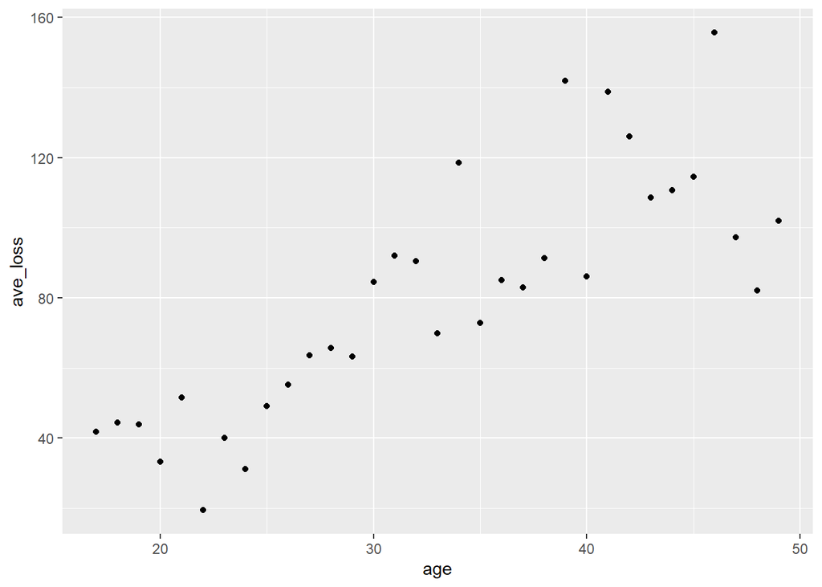

```r
df1 %>%
  filter(age<50) %>%
  group_by(age) %>%
  summarise(ave_loss = mean(as.numeric(capital.loss))) %>%
  ggplot()+geom_point(aes(x=age, y=ave_loss))
```

This shows that as the age increases, the average losses also increases.

- Line Plot

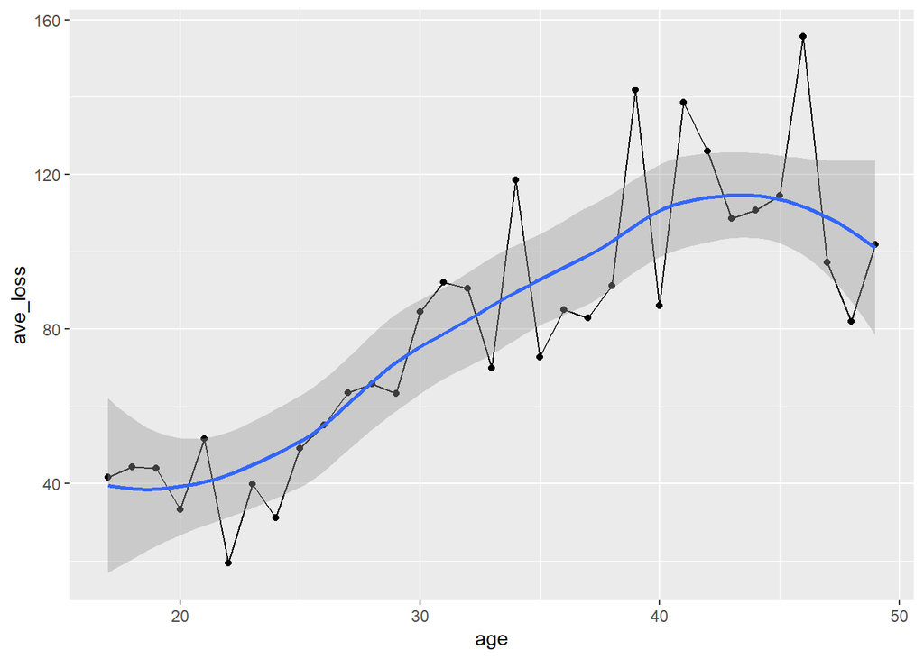

```r
df1 %>%
  select(age, capital.loss) %>%
  filter(age<50) %>%
  group_by(age) %>%
  summarise(ave_loss = mean(as.numeric(capital.loss))) %>%
  ggplot()+
  geom_point(aes(x=age, y=ave_loss))+
  geom_line(aes(x=age, y=ave_loss))+
  geom_smooth(aes(x=age, y=ave_loss))
```

The line plot shows an increase of average loss with many peaks and valleys. The smooth plot depicts the trend without any outliers and and shows the inreasing trend.

4. For one continuous + one categorical variables
- Density

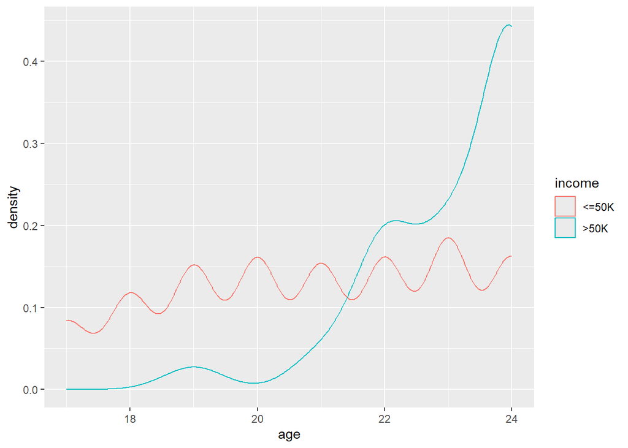

```r
df1 %>%
  filter(age<25) %>%
  ggplot()+
    geom_density(mapping = aes(x = age, color = income))
```

This shows that as age increases, more people start earning >50k.

- BoxPlot

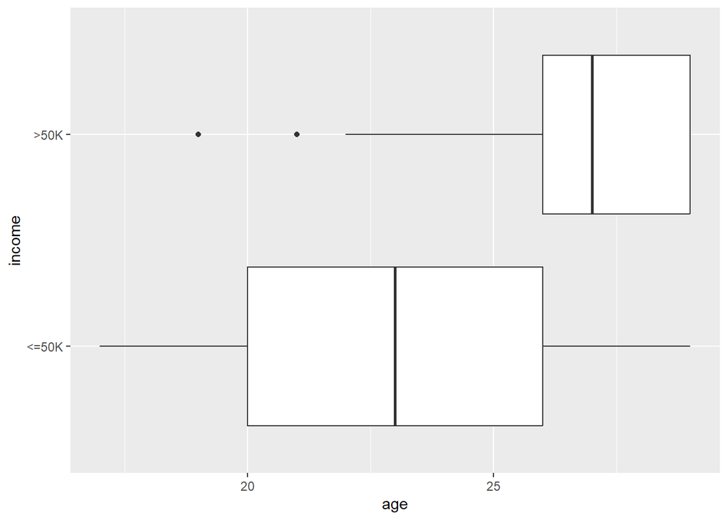

```r
df1 %>%
  filter(age<30) %>%
  ggplot()+
    geom_boxplot(mapping = aes(x = age, y = income))
```

## This box plot shows for those earning less than 50k are about 22.5 and those earning more than 50k have a couple outliers and are over 25.

5. For two categorical variables: barplot

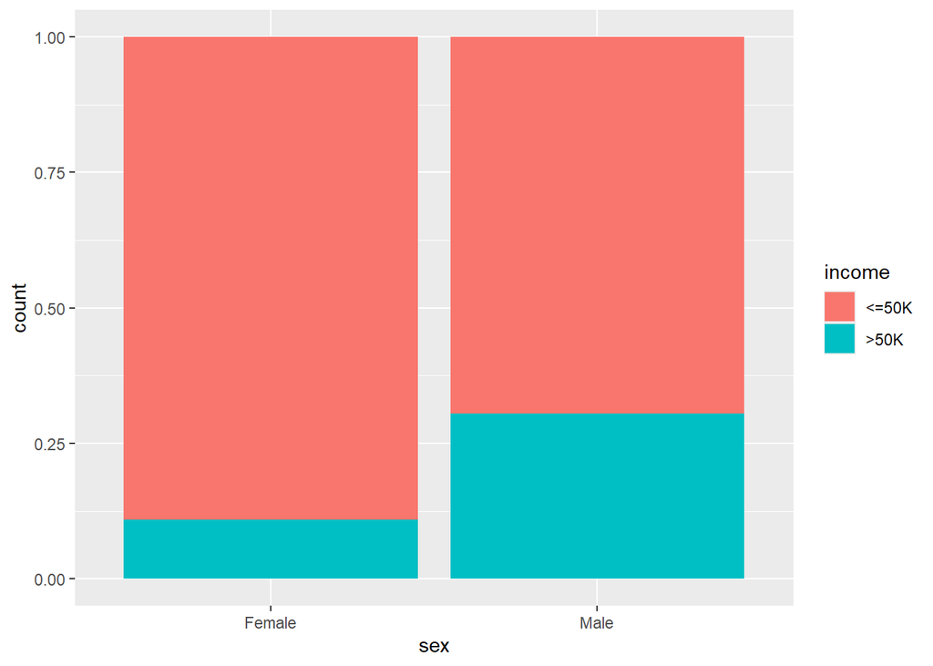

```r
df1 %>% ggplot()+
  geom_bar(mapping=aes(x= sex, fill= income), position = 'fill')
```

This shows that about 10% of females earn over 50k and about 30% of males earn over 50k.

6. A plot that contains three variables

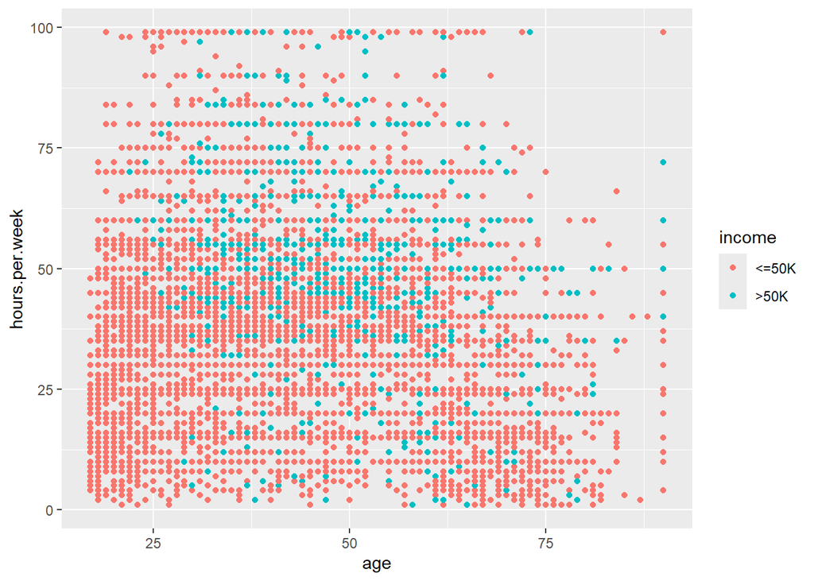

```r
df1 %>% ggplot() + geom_point(aes(x= age, y= hours.per.week, color = income))
```

This shows a trend that a younger age earns less than 50k and that the more hours a person works, the more likely they are earning more than 50k.